# Present a great story for data science projects

This is a Slide Template

2024-08-17

**Important**

**Remember:** Your goal is to make your audience understand and care about your findings. By crafting a compelling story, you can effectively communicate the value of your data science project.

Carefully read this template since it has instructions and tips to writing!

More information about `revealjs`: https://quarto.org/docs/reference/formats/presentations/revealjs.html

## Introduction

- Develop a storyline that captures attention and maintains interest.
- Your audience is your peers
- Clearly state the problem or question you’re addressing.
- Introduce why it is relevant needs.
- Provide an overview of your approach.

## Methods

- Detail the models or algorithms used.
- Justify your choices based on the problem and data.

## Data Exploration and Visualization

- Describe your data sources and collection process.
- Present initial findings and insights through visualizations.
- Highlight unexpected patterns or anomalies.

## Data Exploration and Visualization

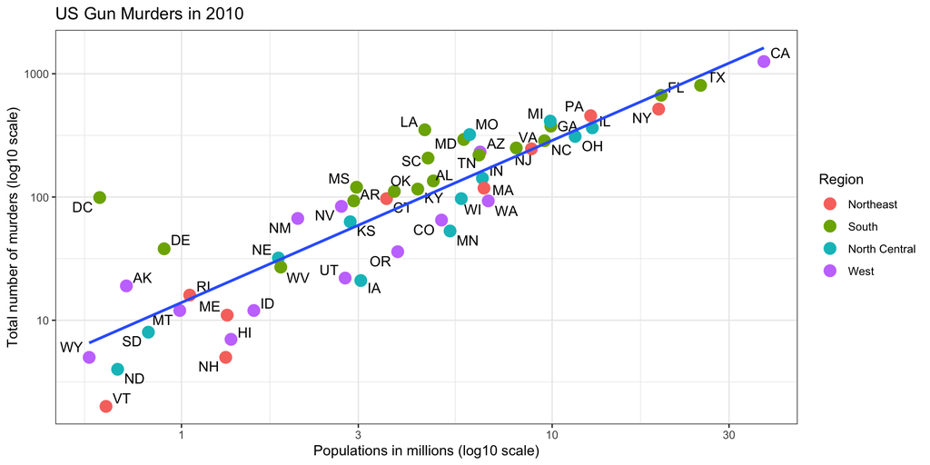

## Modeling and Results

- Explain your data preprocessing and cleaning steps.
- Present your key findings in a clear and concise manner.
- Use visuals to support your claims.
- **Tell a story about what the data reveals.**

## Conclusion

- Summarize your key findings.
- Discuss the implications of your results.

## References

Bro, Rasmus, and Age K Smilde. 2014. “Principal Component Analysis.” *Analytical Methods* 6 (9): 2812–31.

Daffertshofer, Andreas, Claudine JC Lamoth, Onno G Meijer, and Peter J Beek. 2004. “PCA in Studying Coordination and Variability: A Tutorial.” *Clinical Biomechanics* 19 (4): 415–28.

Efromovich, S. 2008. *Nonparametric Curve Estimation: Methods, Theory, and Applications*. Springer Series in Statistics. Springer New York. https://books.google.com/books?id=mdoLBwAAQBAJ.

Wang, Ming. 2014. “Generalized Estimating Equations in Longitudinal Data Analysis: A Review and Recent Developments.” *Advances in Statistics* 2014.